# Montana State University - Data Science Workshop

## Time-series Data

Let’s calculate number of counts per year for each genus.

*Preview of Data Wrangling:* First we need to group the data and count records within each group!

```r
yearly_counts <- BlackfootFish_clean |>
  count(year, species)
  ## counts the number of observations (rows) for each year, species combination
  ## and creates a new variable "n" and creates a new variable "n"

yearly_counts
```

```
## # A tibble: 40 × 3
##     year species     n
##    <dbl> <chr>   <int>
##  1  1989 Brown     238
##  2  1989 Bull       41
##  3  1989 RBT      1338
##  4  1989 WCT        41
##  5  1990 Brown     212
##  6  1990 Bull       35
##  7  1990 RBT      1735
##  8  1990 WCT        97
##  9  1991 Brown     209
## 10  1991 Bull       50
## # ℹ 30 more rows
```

Time series data can be visualized as a line plot with years on the x-axis and counts on the y-axis:

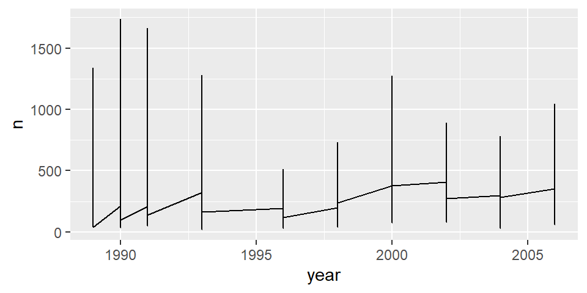

```r
yearly_counts |>
  ggplot(mapping = aes(x = year, y = n)) +
     geom_line()
```

Unfortunately, this does not work because we plotted data for all the species together. We need to tell `ggplot()` to draw a line for each species by modifying the aesthetic function to include `group = species`:

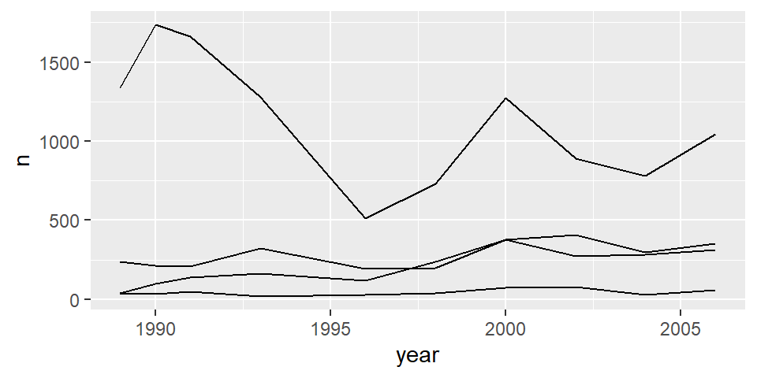

```r
yearly_counts |>
  ggplot(mapping = aes(x = year, y = n, group = species)) +
    geom_line()
```

Unfortunately, we can’t tell what line corresponds to which species. We will be able to distinguish species in the plot if we add colors (using `color` also automatically groups the data):

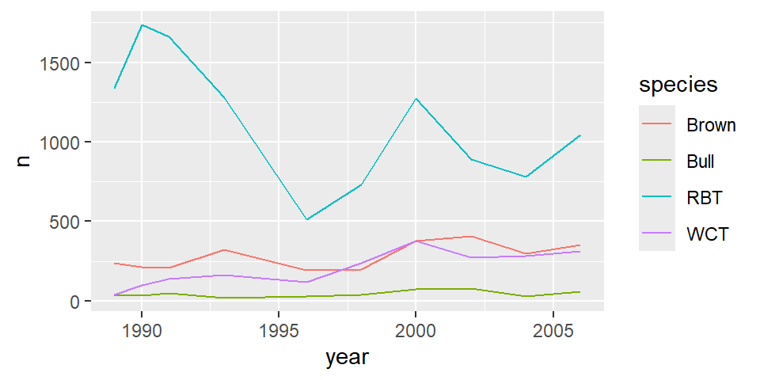

```r
yearly_counts |>
ggplot(mapping = aes(x = year, y = n, color = species)) +
    geom_line()
```

> **Note:** When specifying the color for a line graph, you don’t need to use both the `color = <VARIABLE>` argument and the `group = <VARIABLE>` argument. Both do the same grouping of observations! So you just need to specify the `color` argument.

### Faceting

**`ggplot2`** has a special technique called *faceting* that allows the user to split one plot into multiple plots based on a categorical variable included in the dataset.

There are two types of `facet` functions:

- `facet_wrap()` arranges a one-dimensional sequence of panels to allow them to cleanly fit on one page – used for one variable
- `facet_grid()` allows you to form a matrix of rows and columns of panels – used for two variables

Both geometries allow you to specify faceting variables using formula notation or the `vars()` function. We will use the formula notation, as you will use this notation when creating models (not covered in this workshop).

This looks like: `facet_wrap(facets = ~ facet_variable)` or `facet_grid(row_variable ~ col_variable)`.

Let’s start by using `facet_wrap()` to make a time series plot for each species:

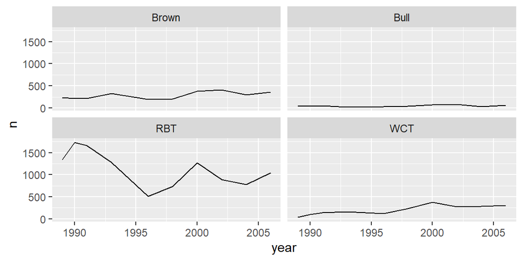

```r
yearly_counts |>
  ggplot(mapping = aes(x = year, y = n)) +
    geom_line() +
    facet_wrap(facets = ~ species)
```

Now we would like to split the line in each plot by the section of the river the fish was captured in. To do that we need to make counts in the data frame grouped by `year`, `species`, and `section`:

```r
yearly_section_counts <- BlackfootFish_clean |>
  count(year, species, section)
## counts the number of observations (rows) for each year, species, section combination

yearly_section_counts
```

```
## # A tibble: 79 × 4
##     year species section         n
##    <dbl> <chr>   <chr>       <int>
##  1  1989 Brown   Johnsrud       93
##  2  1989 Brown   ScottyBrown   145
##  3  1989 Bull    Johnsrud       23
##  4  1989 Bull    ScottyBrown    18
##  5  1989 RBT     Johnsrud     1050
##  6  1989 RBT     ScottyBrown   288
##  7  1989 WCT     Johnsrud       20
##  8  1989 WCT     ScottyBrown    21
##  9  1990 Brown   Johnsrud       92
## 10  1990 Brown   ScottyBrown   120
## # ℹ 69 more rows
```

We can now make the faceted plot by splitting further by section using `color` (within each panel):

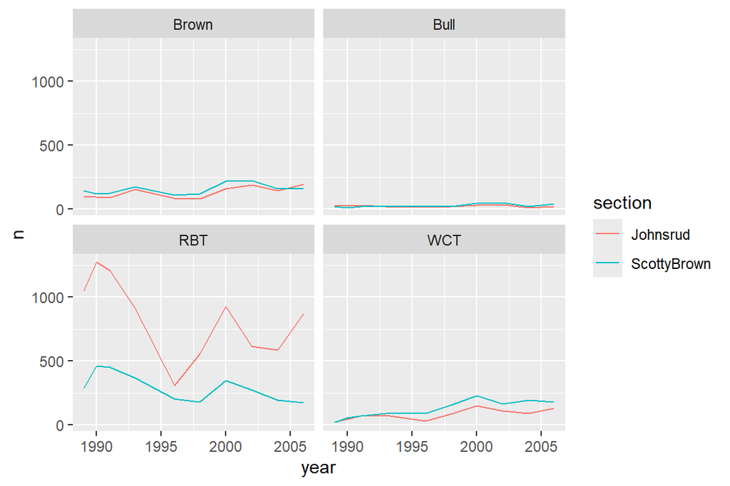

```r
yearly_section_counts |>
  ggplot(mapping = aes(x = year, y = n, color = section)) +
    geom_line() +
    facet_wrap(facets =  ~ species)
```

You can also organize the panels only by rows (or only by columns), using the optional `nrow` and `ncol` arguments:

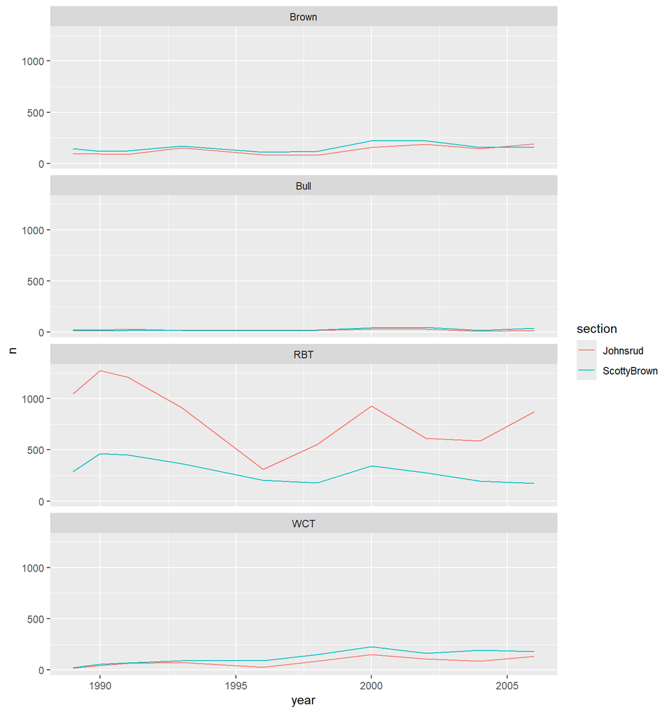

```r
yearly_section_counts |>
  ggplot(mapping = aes(x = year, y = n, color = section)) +
    geom_line() +
    facet_wrap(facets =  ~ species, ncol = 1)
```

```r
  # One column, facet by rows
```

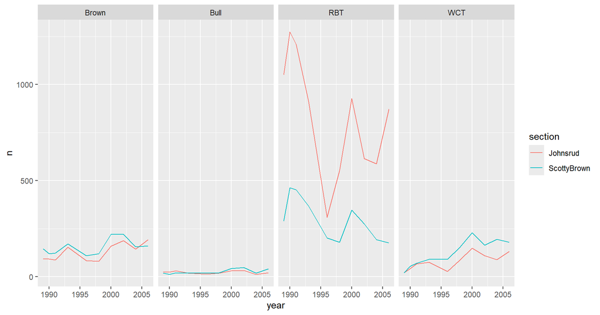

```r
yearly_section_counts |>
  ggplot(mapping = aes(x = year, y = n, color = section)) +
    geom_line() +
    facet_wrap(facets =  ~ species, nrow = 1)
```

```r
  # One row, facet by columns
```

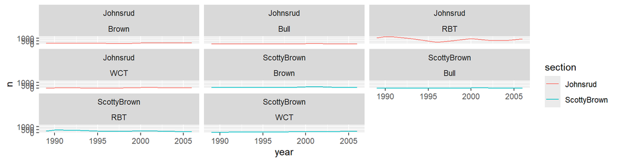

```r
yearly_section_counts |>
  ggplot(mapping = aes(x = year, y = n, color = section)) +
    geom_line() +
    facet_wrap(section ~ species)
```

### Challenge 12

> Use what you just learned to create a plot that depicts how the average weight of each species changes through the years. Play around with which variable you facet by versus plot by!

```r
## To get you started:
yearly_species_weight <- BlackfootFish_clean |>
  group_by(year, species) |>
  ## Variables to group by
  summarize(avg_weight = mean(weight))
```

```
## `summarise()` has regrouped the output.
## ℹ Summaries were computed grouped by year and species.
## ℹ Output is grouped by year.
## ℹ Use `summarise(.groups = "drop_last")` to silence this message.
## ℹ Use `summarise(.by = c(year, species))` for per-operation grouping
##   (`?dplyr::dplyr_by`) instead.
```

```r
## Edit the following ggplot() code for the plot here:
yearly_species_weight |>
  ggplot(mapping = aes(x = year, y = n, color = avg_weight)) +
    geom_line() +
    facet_wrap(facets =  ~ species)
```

```
## Defaulting to continuous.
```

[output not shown]

```r
## Your ggplot() code for the plot goes here!
```

## **`ggplot2`** Themes

Usually plots with white background look more readable when printed. Every single component of a `ggplot()` graph can be customized using the generic `theme()` function, as we will see below. However, there are pre-loaded themes available that change the overall appearance of the graph without much effort.

For example, we can change our previous graph to have a simpler white background using the `theme_bw()` function:

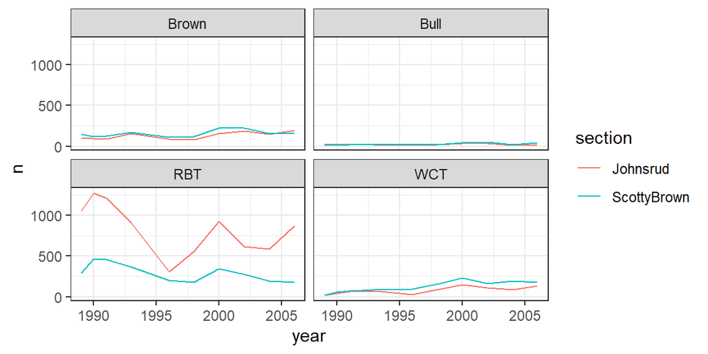

```r
yearly_section_counts |>
 ggplot(mapping = aes(x = year, y = n, color = section)) +
     geom_line() +
     facet_wrap(~ species) +
     theme_bw()
```

In addition to `theme_bw()`, which changes the plot background to white, **`ggplot2`**comes with several other themes which can be useful to quickly change the look of your visualization. The complete list of themes is available at https://ggplot2.tidyverse.org/reference/ggtheme.html. `theme_minimal()` and `theme_light()` are popular, and `theme_void()` can be useful as a starting point to create a new hand-crafted theme.

The [ggthemes](https://jrnold.github.io/ggthemes/reference/index.html) package provides a wide variety of options. The [**`ggplot2`** extensions website](https://exts.ggplot2.tidyverse.org/) provides a list of packages that extend the capabilities of **`ggplot2`**, including additional themes.

### Challenge 13

> Use what you just learned to add the plotting background theme of your choosing to the plot you made in Challenge 7!

```r
## Your ggplot() code for the plot goes here!
```

## Customization

Take a look at the [**`ggplot2`** cheat sheet](https://github.com/rstudio/cheatsheets/blob/main/data-visualization-2.1.pdf), and think of ways you could improve the previous plot.

### Plot Labels

Now, let’s change names of axes to something more informative than ‘year’ and ‘n’ and add a title to the figure. Label customizations are done using the `labs()` function like so:

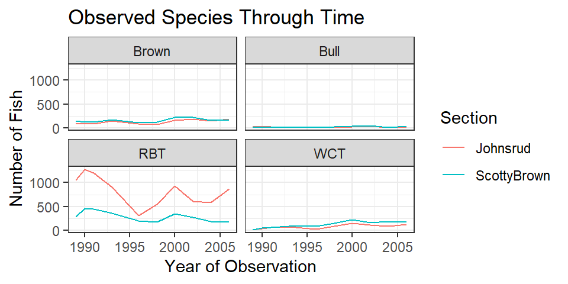

```r
yearly_section_counts |>
 ggplot(mapping = aes(x = year, y = n, color = section)) +
     geom_line() +
     facet_wrap(~ species) +
     theme_bw() +
  labs(title = "Observed Species Through Time",
       x = "Year of Observation",
       y = "Number of Fish",
       color = "Section")
```

> **Tip: Wrapping Titles**

> Sometimes the titles we wish to have for our plots are longer than the space originally allotted. If you create a title and the text is running off the plot you can add a `\n` inside your title to force a line break (`\n` stands for new line).

### Label & Plot Fonts

Note that it is also possible to change the fonts of your plots. If you are on Windows, you may have to install the [**`extrafont`** package](https://github.com/wch/extrafont), and follow the instructions included in the README for this package.

In the last plot, the axes have more informative names, but their readability can be improved by increasing the font size. This can be done with the generic `theme()` function.

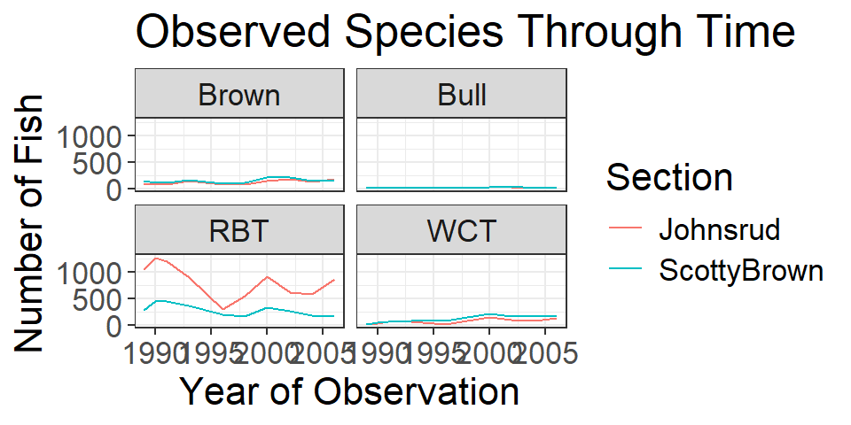

```r
yearly_section_counts |>
 ggplot(mapping = aes(x = year, y = n, color = section)) +
     geom_line() +
     facet_wrap(~ species) +
     theme_bw() +
  labs(title = "Observed Species Through Time",
       x = "Year of Observation",
       y = "Number of Fish",
       color = "Section")  +
  theme(text = element_text(size = 16))
```

```r
    ## sets ALL the text on the plot to be size 16
```

**Note:**  
`theme_bw()` is a function for a **specific** theme and `theme()` is a generic function for a **variety** of different themes!

After our manipulations, you may notice that the values on the x-axis are still not properly readable. Let’s swap the orientation of the labels, so the reader doesn’t have to tilt their head when reading our plot! The `coord_flip()` function easily changes the x- and y-axis.

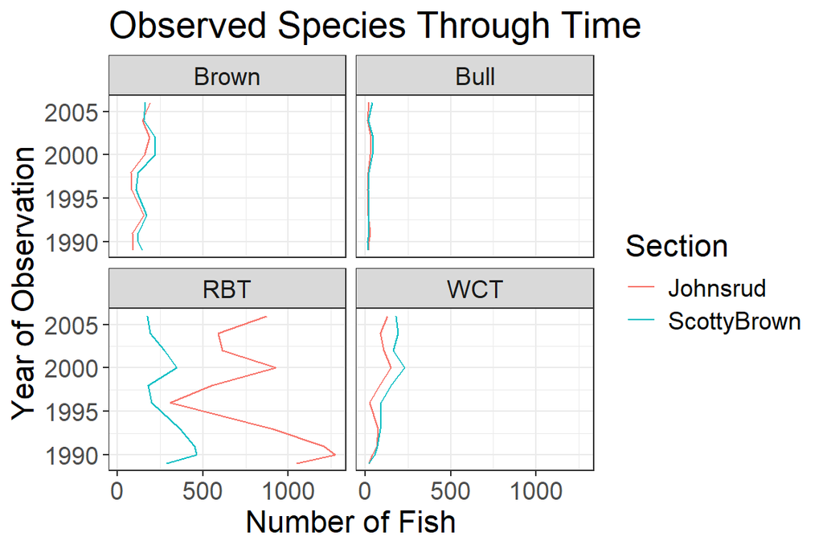

```r
yearly_section_counts |>
 ggplot(mapping = aes(x = year, y = n, color = section)) +
     geom_line() +
     facet_wrap(~ species) +
     theme_bw() +
  labs(title = "Observed Species Through Time",
       x = "Year of Observation",
       y = "Number of Fish",
       color = "Section")  +
  theme(text = element_text(size = 16)) +
  coord_flip()
```

This definitely makes the reader tilt their head less! For further refinement, we can specify the text size for each element of the plot independently. This would look something like this:

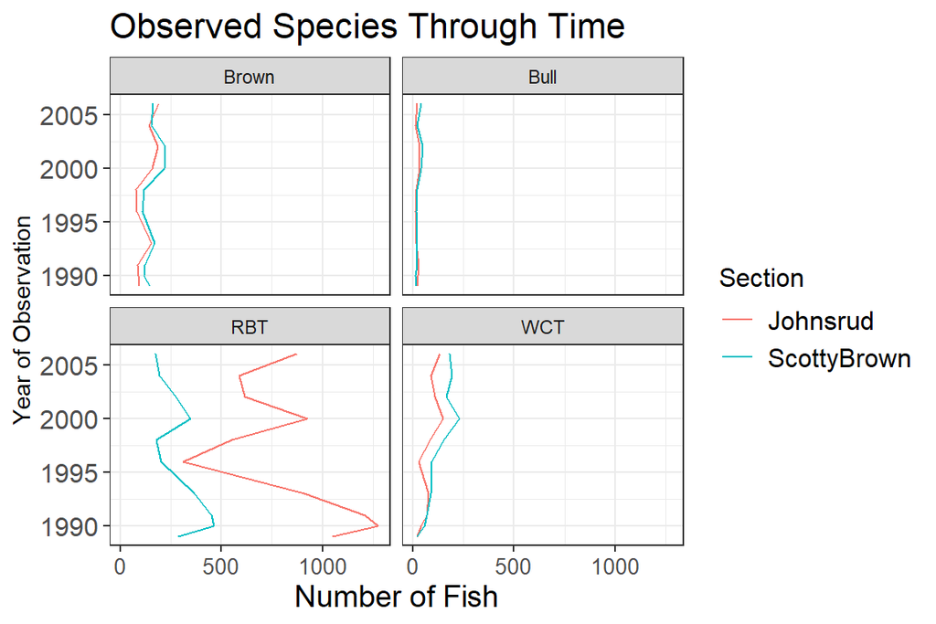

```r
yearly_section_counts |>
 ggplot(mapping = aes(x = year, y = n, color = section)) +
     geom_line() +
     facet_wrap(~ species) +
     theme_bw() +
  labs(title = "Observed Species Through Time",
       x = "Year of Observation",
       y = "Number of Fish",
       color = "Section") +
  theme(axis.text.x = element_text(size = 10),
        axis.text.y = element_text(size = 12),
        axis.title.x = element_text(size = 14),
        legend.text = element_text(size = 12),
        legend.title = element_text(size = 12),
        plot.title = element_text(size = 16)) +
  coord_flip()
```

### Legend Position

By default in `ggplot2` the legend is positioned on the right hand side. However, you are able to change the position of the legend to the left hand side, the top of the plot, or the bottom of the plot.

This is done by adding a `legend.position` theme to the plot’s `theme()`’s.

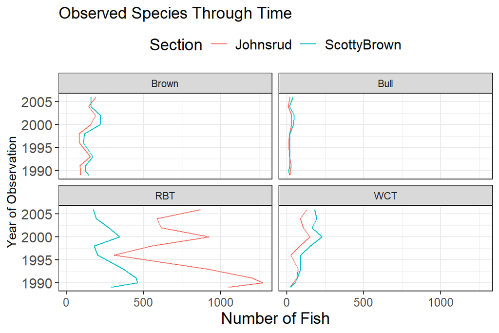

```r
yearly_section_counts |>
 ggplot(mapping = aes(x = year, y = n, color = section)) +
     geom_line() +
     facet_wrap(~ species) +
     theme_bw() +
  labs(title = "Observed Species Through Time",
       x = "Year of Observation",
       y = "Number of Fish",
       color = "Section")  +
  theme_bw() +
  theme(axis.text.x = element_text(size = 10),
        axis.text.y = element_text(size = 12),
        axis.title.x = element_text(size = 14),
        legend.text = element_text(size = 12),
        legend.title = element_text(size = 14),
        plot.title = element_text(size = 14),
        legend.position = "top") +
  coord_flip()
```

### Removing Grid Lines

By default, the background of a `ggplot()` contains both minor and major gridlines. These can make the plot look a bit busy and sometimes difficult for the reader to follow. As you may have guessed, to remove these gridlines, we add another theme to our plot.

This looks like this:

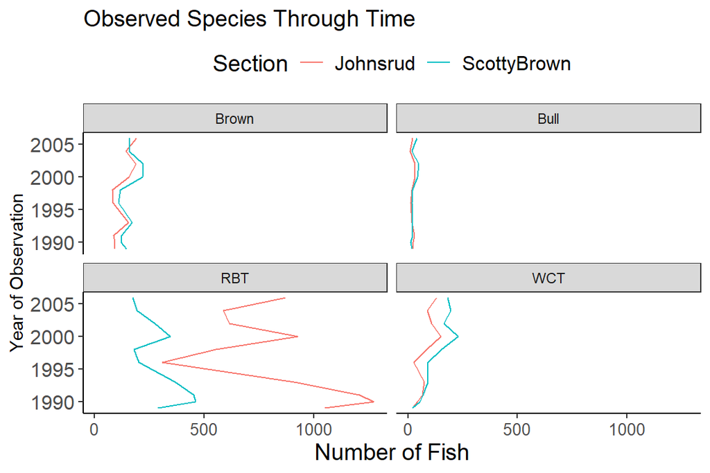

```r
yearly_section_counts |>
 ggplot(mapping = aes(x = year, y = n, color = section)) +
     geom_line() +
     facet_wrap(~ species) +
     theme_bw() +
  labs(title = "Observed Species Through Time",
       x = "Year of Observation",
       y = "Number of Fish",
       color = "Section")  +
  theme(axis.text.x = element_text(size = 10),
        axis.text.y = element_text(size = 12),
        axis.title.x = element_text(size = 14),
        legend.text = element_text(size = 12),
        legend.title = element_text(size = 14),
        plot.title = element_text(size = 14),
        legend.position = "top",
        ## New themes for the grid lines
        axis.line = element_line(color = "black"),
        ##
        panel.grid.major = element_blank(),
        panel.grid.minor = element_blank(),
        panel.border = element_blank(),
        panel.background = element_blank()) +
  coord_flip()
```

Let’s break these options down!

- The `axis.line` option declares what color the x- and y-axis lines should be. (Change it to a different color, if you don’t believe me!)
- The `panel.grid.major` removes the major grid (the one associated with the ticks from the x- and y-axis).
- The `panel.grid.minor` removes the minor grid (the one *between* the x- and y-axis ticks).
- The `panel.border` removes the border around the plot.
- The `panel.background` performs a similar action to `theme_bw()`, but it keeps the border around the facet labels.

### Changing Colors

The built in `ggplot()` color scheme may not be what you were looking for, but don’t worry! There are many other color palettes available to use!

You can change the colors used by `ggplot()` a few different ways.

#### Manual Specification

Add the `scale_color_manual()` or `scale_fill_manual()` functions to your plot and directly specify the colors you want to use. You can either:

- defining a vector of colors right there (e.g. `values = c("blue", "black", "red", "green")`)
- creating a vector of colors and storing it in an object and calling it (see below)

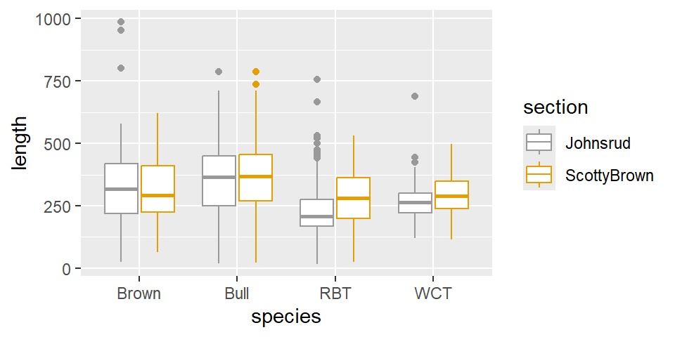

```r
# A color deficient friendly palette with grey:
cbPalette_grey <- c("#999999", "#E69F00", "#56B4E9", "#009E73", "#F0E442",
                    "#0072B2", "#D55E00", "#CC79A7")

# A color deficient friendly palette with black:
cbPalette_blk <- c("#000000", "#E69F00", "#56B4E9", "#009E73", "#F0E442",
                   "#0072B2", "#D55E00", "#CC79A7")

BlackfootFish_clean |>
  ggplot(aes(x = species, y = length, color = section)) +
  geom_boxplot() +
  scale_color_manual(values = cbPalette_grey)
```

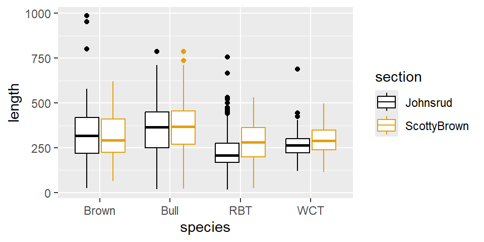

```r
BlackfootFish_clean |>
  ggplot(aes(x = species, y = length, color = section)) +
  geom_boxplot() +
  scale_color_manual(values = cbPalette_blk)
```

#### Package Specification

Install a package and use it’s available color scales. Popular options include:

- `RColorBrewer`: using `scale_fill_brewer()` or `scale_color_brewer()`
- `viridis`: using `scale_color_viridis_d()` for discrete data, `scale_color_viridis_c()` for continuous data, with an inside argument of `option = <COLOR>` for your chosen color scheme
- `ggsci`: using `scale_color_<PALNAME>()` or `scale_fill_<PALNAME>()`, where you specify the name of the palette you wish to use (e.g., `scale_color_aaas()`)

### Challenge 14

> With all of this information in hand, please take another five minutes to either improve one of the plots generated in this exercise or create a beautiful graph of your own. Use the RStudio [**`ggplot2`** cheat sheet](https://github.com/rstudio/cheatsheets/raw/master/data-visualization-2.1.pdf) for inspiration. Here are some ideas:
> - See if you can change the thickness of the lines.
> - Try using a different color palette
> - Can you find a way to change the name of the legend? What about its labels? (see http://www.cookbook-r.com/Graphs/Colors_(ggplot2)/).

```r
## your code for the challenge goes here!
```

## Arranging Plots

Faceting is a great tool for splitting one plot into multiple plots, but sometimes you may want to produce a single figure that contains multiple plots using different variables or even different data frames. The **`gridExtra`** package allows us to combine separate ggplots into a single figure using `grid.arrange()` (make sure to scroll down in the window to see all the code):

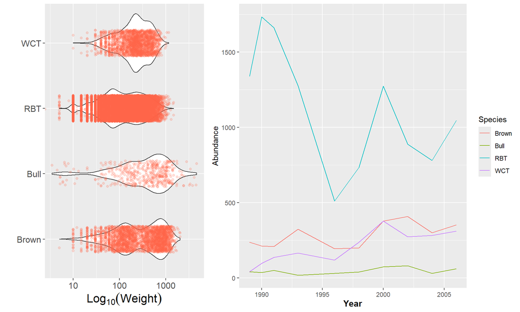

```r
library(gridExtra)

spp_weight_boxplot <- BlackfootFish_clean |>
  ggplot(aes(x = species, y = weight)) +
  geom_violin() +
  geom_jitter(color = "tomato", width = 0.2, alpha = 0.2) +
  scale_y_log10() +
  ## log (base 10) transforms the y-axis variable
  ## (helps to make the plot less skewed)
  labs(x = "",
       ## removes the y-axis label
       y = expression(Log[10](Weight))) +
       ## Expression creates a mathematical expression in the axis label
       ## the [10] refers to the subscript next to Log
  coord_flip() +
  theme(axis.text.y = element_text(size = 12),
        axis.text.x = element_text(size = 12),
        text = element_text(size = 16))

spp_count_plot <- yearly_counts |>
  ggplot(aes(x = year, y = n, color = species)) +
  geom_line() +
  labs(x = "Year",
       y = "Abundance",
       color = "Species") +
  theme(axis.title.x = element_text(face = "bold", size = 12))
  ## To make your axis title boldface, this is what you need!

grid.arrange(spp_weight_boxplot, spp_count_plot, ncol = 2, widths = c(4, 6))
```

```r
## nrow and ncol specify how many rows/columns you want the arranged plots to be in
## widths specify what proportion of the overall plotting area each plot takes up
```

In addition to the `ncol` and `nrow` arguments, used to make simple arrangements, there are tools for [constructing more complex layouts](https://cran.r-project.org/web/packages/gridExtra/vignettes/arrangeGrob.html).

For more assistance arranging plots with `grid.arrage()`. We find the following vignette **very** helpful! https://cran.r-project.org/web/packages/egg/vignettes/Ecosystem.html

Another option for combining plots is the [patchwork package](https://patchwork.data-imaginist.com/). It uses a sort of formula interface for defining the layout of multiple plots. For example, you can get two plots side-by-side in a one row, two column array with `p1 + p2` and two plots stacked into two rows and one column with `p1 / p2`. This provides both a quick and powerful way to arrange ggplots you have created.

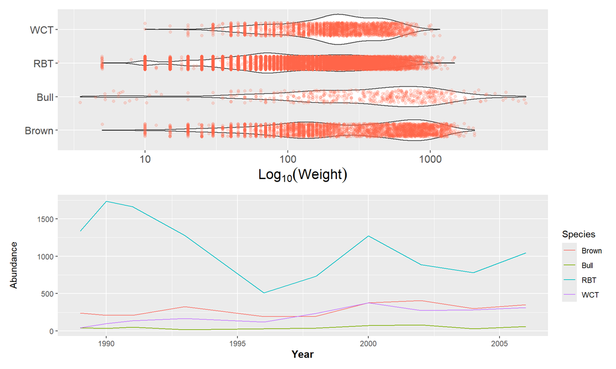

```r
spp_weight_boxplot / spp_count_plot
```

## Exporting Plots

After creating your plot, you can save it to a file in your favorite format. The Export tab in the **Plot** pane in RStudio will save your plots at low resolution, which will not be accepted by many journals and will not scale well for posters.

Instead, use the `ggsave()` function, which allows you easily change the dimension and resolution of your plot by adjusting the appropriate arguments:

- `width` and `height`: adjust the total plot size in units (“in”, “cm”, or “mm”)
  - If units are not specified, default is inches.
- `dpi`: adjusts the plot resolution. This accepts a string or numeric input:
  - “retina” (320)
  - “print” (300)
  - “screen” (72)

Make sure you have the `fig/` folder in your working directory. The first line of code checks to see if that folder exists, and if not, creates it.

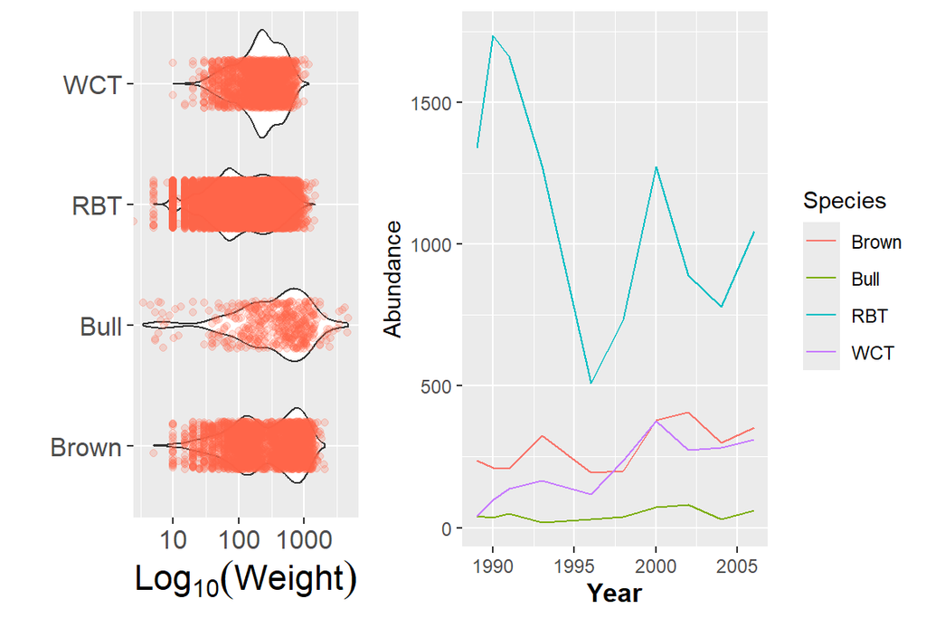

```r
# Specify where you want figures to be saved relative to current directory
if(!dir.exists("fig")){dir.create("fig")}

my_plot <- ggplot(data = yearly_section_counts,
                  mapping = aes(x = year, y = n, color = section)) +
              geom_line() +
              facet_wrap(~ species) +
              labs(title = "Observed species through time",
                    x = "Year of observation",
                    y = "Number of individuals") +
              theme_bw() +
              coord_flip() +
              theme(axis.text.y = element_text(color = "grey20", size = 12),
                    text = element_text(size = 16))

ggsave("fig/yearly_section_counts.png", my_plot, width = 15, height = 10)

# This also works for grid.arrange() plots
combo_plot <- grid.arrange(spp_weight_boxplot, spp_count_plot,
                           ncol = 2, widths = c(4, 6))
```

```r
ggsave("fig/combo_plot_abun_weight.png", combo_plot, width = 10, dpi = 300)
```

> **Note:** The parameters `width` and `height` also determine the font size in the saved plot.

### Interactive Graphics (Bonus Material)

In certain situations, static displays can limit the sorts of information available and do not allow easy interrogation for information on individual aspects of plots. Obviously, most print journals do not have a way to have readers interact with the printed page, but in digital venues there are some possibilities. Of particular interest here are interactive graphics that can function on websites and in blog posts or even in certain presentation formats. One way to do this that leverages the previous work in making `ggplot`-style graphics is using the `ggplotly` function from the `plotly` R package (Sievert, 2020). You can access the 2020 book that goes into more detail on `plotly`-style graphics at https://plotly-r.com/.

To use `ggplotly`, we wrap that function around a `ggplot` object and it will render it in an interactive fashion when the viewer hovers over individual plot components. There are also ways of making `plotly` graphs directly using `plot_ly` and that may prove easier for some things, for example for making interactive three-dimensional graphs.

Here are two examples that we worked with earlier converted into `ggplotly` objects that allow further interrogation of the information displayed:

```r
if(!("plotly" %in% rownames(installed.packages()))){install.packages("plotly")}

library(plotly)

spp_weight_boxplot <- BlackfootFish_clean |>
  ggplot(aes(x = species, y = weight)) +
  geom_violin() +
  geom_jitter(color = "tomato", width = 0.2, alpha = 0.2) +
  scale_y_log10() +
  ## log (base 10) transforms the y-axis variable
  ## (helps to make the plot less skewed)
  labs(x = "",
       ## removes the y-axis label
       y = "log10-Weight") +
  coord_flip() + #Switches x and y axes
  theme(axis.text.y = element_text(size = 12),
        axis.text.x = element_text(size = 12),
        text = element_text(size = 16)) +
  theme_bw()

spp_count_plot <- yearly_counts |>
  ggplot(aes(x = year, y = n, color = species)) +
  geom_line() +
  labs(x = "Year",
       y = "Abundance",
       color = "Species") +
  theme(axis.title.x = element_text(face = "bold", size = 12)) +
  theme_bw()

ggplotly(spp_weight_boxplot);ggplotly(spp_count_plot)
```

[output not shown]

One note about using `plotly` graphics in R-markdown is that they will not knit into word or PDF formats, only into HTML (in word or PDF, you are stuck with static images but you could incorporate a link to a website containing the interactive version of the plot). You can also interact with plots when working in markdown or running code in the console in RStudio. For presentations, you can also record a video of interactions with plot to remove some challenges of live presentations using this format. But if you are looking to wow your viewers in a digital format, need to dig into some details of what is displayed in a plot quickly, or when static graphics are limiting your story-telling ability, remember that there might be another option!

# Coding with Generative AI

# Appendix

## Terminology Used in Workshop

- *Command*: A command is what `R` executes. In an `R` script file (script.R), commands are automatically implied, as this type of file does not accept text, only in comments. In an Rmd (Markdown) file (report.Rmd), commands are delineated between three ticks on the top (`` ```{r} ``) and three ticks (`` ``` ``) on the bottom.

  ````
  ```{r}
  # Your code goes here
  ```
  ````

- *Comment*: Helpful text added into a script environment. Comments can be used to describe functions, processes, a train of thought, so that when you return to your code, tomorrow or next year, you are able to understand the purpose of each line of code! Comments are preceded by at least on `#` within a code chunk.
- *Object*: A variable created in `R`, to be used elsewhere in the code. Objects can be a variety of things, such as scalars (`x <- 3`), vectors (`x <- c(1, 2, 3, 4, 5)`), matrices, and dataframes, to name a few.
- *Assignment Arrow*: The assignment arrow `<-` is used to assign values on the right to the objects on the left (`x <- 1`). For historical reasons, you can also use `=` for assignments, but not everywhere. Because of these slight differences, it is recommended to *always* use assignment arrows for assignment.
- *Class*: Most `R` objects have a class attribute, a character vector giving the names of the classes from which the object inherits. Examples of classes are numeric, factor, integer, character, dataframe, matrix, list.
- *Vector*: A vector is a list of entries, all sharing the same class. A vector has only one dimension, so data extraction uses only a single entry in brackets (e.g. `x[3]`). You can create vectors of characters (`c("a", "b", "c")`), vectors of numbers (`c(1, 2, 3)`), to name a few.
- *Matrix*: Similar to what you may have seen in a mathematics class, a matrix is an object with rows and columns, where every entry in the matrix must be a number.
- *List*: A generic vector, which contains other objects. A list can contain a variety of different classes of objects, e.g., characters, vectors, data.frames, matrices, or outputs from a model! A data.frame is a special type of list where the components are vectors and they all have the same length.
- *Dataframe*: A dataframe is a collection of variables. Dataframes share many of the properties of matrices, where you are able to extract elements using bracket (`[]`) notation, and lists, where you are able to extract columns using `$`. Dataframes are used as the fundamental data structure by most of `R`’s statistical modeling software. Note that tibbles have been more recently created as part of the tidyverse and provide a similar but slightly different object where you can store your data.
- *Argument*: Input(s) into a function, so that an output is created. Most functions take named arguments (e.g., `data = BlackfootFish`) and the order of the arguments is assumed to follow the order found in the function’s help file. When using a named argument in a function, the name comes first, followed by an `=` sign, then the input.
- *Logical Value*: `TRUE` and `FALSE` value(s) that can be used to turn off/on options in functions and plots, and also to manipulate data.

## Workshop Materials & Recordings Available:

- email Sara Mannheimer (sara.mannheimer@montana.edu)
- through the MSU Library Data Science website (http://www.montana.edu/datascience/)

## How to Learn More About `R` and `RStudio`

This material is intended to provide you with an introduction to using `R` for scientific analyses of data. The best way for you to continue to learn more about `R` is to use it in your research! This may sound daunting, but writing `R` scripts is the best way to become familiar with the syntax. This will help you progress through more advanced operations, such as cleaning your data, using statistical methods, or creating graphics.

The best place to start is playing around with the code from today’s workshop. Change parts of the code and see what happens! Better yet, use the code from the workshop to investigate your own data!

### Clean Code

Yes, writing code may be completely new to you, but there is a difference between code that looks nice and code that does not. Generally, object names should be nouns and function names should be verbs. It is also important that your code looks presentable, so that a friend/college/professor can read it and understand what you are doing. For these reasons, there are style guides for writing code in `R`. The two main style guides are Google’s https://google.github.io/styleguide/Rguide.xml and the slightly more comprehensive Tidyverse style guide https://style.tidyverse.org/. Installing the `styler` package will allow you to highlight code and format it in a more legible way. Visit the tidyverse page https://style.tidyverse.org/ for more information.

### Projects in `RStudio`

`R` projects provide a way to organize all the code and data in one place and many consider these the best way to work in `R`. We chose to avoid this step and just use a single .Rmd file to expedite your first experience using `R`. A motivation for using projects is that it is important to organize your data and script files into the same or related locations and have different locations for different iterations of projects. If you don’t do this:

- it is really hard to tell which version of your data is original and what versions are modified
- things get really messy because all types of files are mixed together
- it’s probably hard for you to find things and relate the correct files to their respective output

Ultimately, good project organization will make your life easier! It helps ensure the integrity of your data, makes it simpler to share your code or get help with your code, allows for you know exactly what code you used on a paper, and it’s easier to pick a project back up.

It is good code writing and file storage practice to keep a set of all related data, analysis, plots, documents, etc. in the same folder. RStudio makes this process easy with using their projects. In an RStudio project, all of the project’s pieces are in the same folder. This allows for a clean workflow and a simple working directory for `R`. When you are executing code for a document/script `R` will search for things (such as data) in the folder as the document/script, which is called a *relative path*.

Whenever you start working on a new project in RStudio, go through the following steps:

1. Click on the “File” menu button, then select “New Project”
2. Click “New Directory”
3. Click “New Project”
4. Create a name for your project (make it explanatory!)
5. Select where the project should live
6. Click the “Create Project” button
7. Open the project!

After this process `R` will be searching for objects (such as data) in the folder as the project. This allows for us to keep all of our files in a self-contained system.

After saving your previous work today, you can try to create a project in a new folder on your computer. After you create the project, you can create a new .Rmd file and copy and paste the text from this document into this file. And move a copy of the BlackfootFish.csv into the project folder you created. Whenever you open this project it will take you directly to the work you have done in that project folder. It may be useful to close the project before exiting RStudio to avoid confusion in later sessions.

## Lists

While the elements of vectors have to be of the same data type, a list is a special vector in `R` that allows for you to store a variety of types of objects. If you have a vector, a matrix, and/or a character, you can store all of them into one list object!

The arguments to the list function are the components of the list, where the components can be characters, vectors, matrices, or other data structures. Here, we create a list whose components are the three vectors we created in the Introduction to R chapter:

```r
my_first_list <- list(animals, temps, logic)
my_first_list
```

```
## [[1]]
## [1] "cat"  "dog"  "bird" "fish"
##
## [[2]]
## [1] 50 55 60 65
##
## [[3]]
## [1]  TRUE FALSE FALSE  TRUE
```

```r
my_first_list[[1]]
```

```
## [1] "cat"  "dog"  "bird" "fish"
```

We notice that when printing a list, the output looks a bit different. There are a whole bunch of brackets! Let’s break them down. I like to think of a list as a shelf with cubby holes. The cubby holes are the components of the list, but there are elements in each cubby. See Figure 2.

- To get to a specific component (cubby) of a list, you use the double brackets next to the name of the list (e.g `my_first_list[[1]]`).
- To access the elements inside each cubby, you then use single square brackets (e.g. `my_first_list[[1]][2]`).

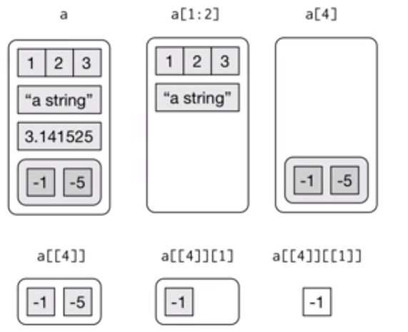

Example of lists

### Named Lists

```r
my_named_list <- list(title = "statistics",
                      numbers = 1:10,
                      data = TRUE)
my_named_list
```

```
## $title
## [1] "statistics"
##
## $numbers
##  [1]  1  2  3  4  5  6  7  8  9 10
##
## $data
## [1] TRUE
```

We see the output for a named list is slightly different. Instead of double brackets next to each component, there are now `$` and names of the items in the list, these can be variables, parameters, or other information. This will help you understand the structure of data.frames.

## Data Visualization using Base `R`

There are many different genres of data graphics, with many different variations on each genre. Here are some commonly encountered kinds:

- **scatterplots**: showing relationships between two quantitative variables
- **distributions**: showing distributions of a single quantitative variable
- **bar charts**: displaying frequencies or densities of a single categorical variable

We will include this code for reference, but will skip this section, as we will go over data visualization using `ggplot2` in the next workshop session.

### Scatterplots

The main purpose of the scatterplot is to show the relationship between two variables across several or many cases. Most often, there is a Cartesian coordinate system in which the x-axis represents one variable and the y-axis the second variable.

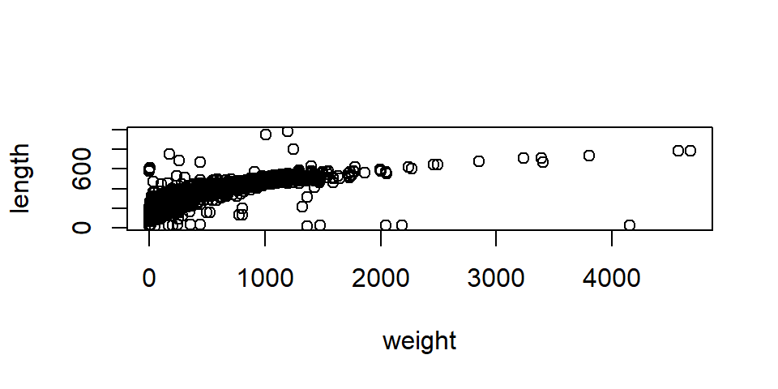

```r
#?plot()
plot(length ~ weight,
     data = BlackfootFish_clean)
```

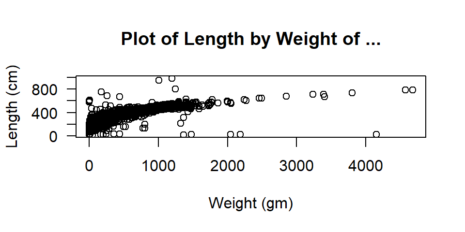

```r
plot(length ~ weight,
     data = BlackfootFish_clean,
     xlab = "Weight (gm)", ## adding in axis labels
     ylab = "Length (cm)",
     las = 1, ## changing orientation of y-axis labels,
     main = "Plot of Length by Weight of ..." ## adds a title
     )
```

### Distribution

A histogram shows how many observations fall into a given range of values of a variable and can be used to visualize the distribution of a single quantitative variable.

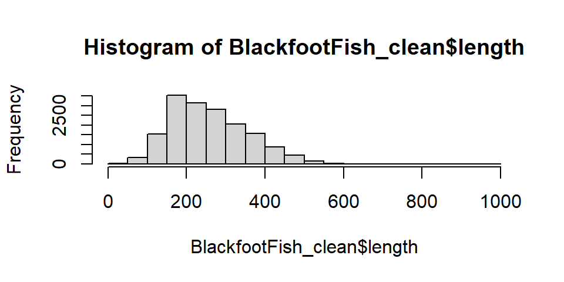

```r
hist(BlackfootFish_clean$length)
```

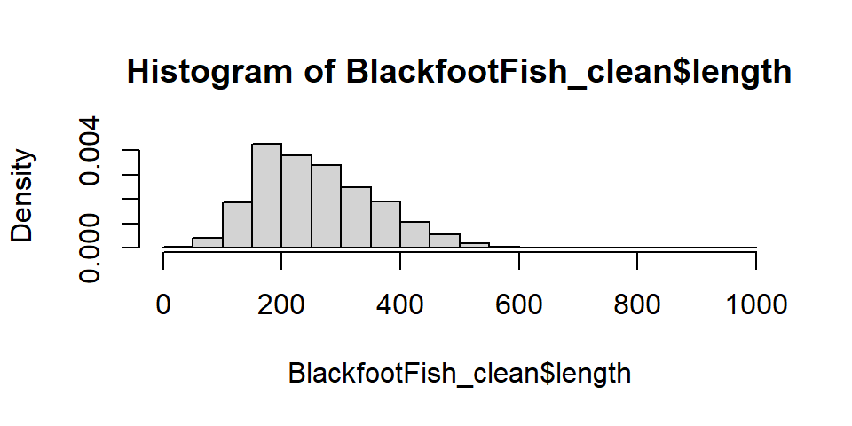

```r
hist(BlackfootFish_clean$length,
     freq = F) ## converts to a density plot (area adds to 1)
```

```r
## Does freq need to be named?
hist(BlackfootFish_clean$length, FALSE)
```

```
## Error in `hist.default()`:
## ! invalid number of 'breaks'
```

```r
## Why is there an error about the "number of breaks"?
```

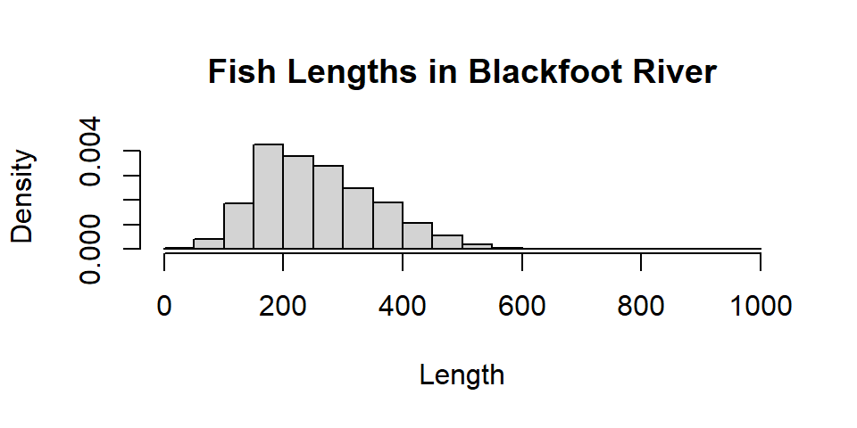

```r
hist(BlackfootFish_clean$length,
     freq = F,
     xlab = "Length", ## adds x-axis label
     main = "Fish Lengths in Blackfoot River" ## adds title to plot
     )
```

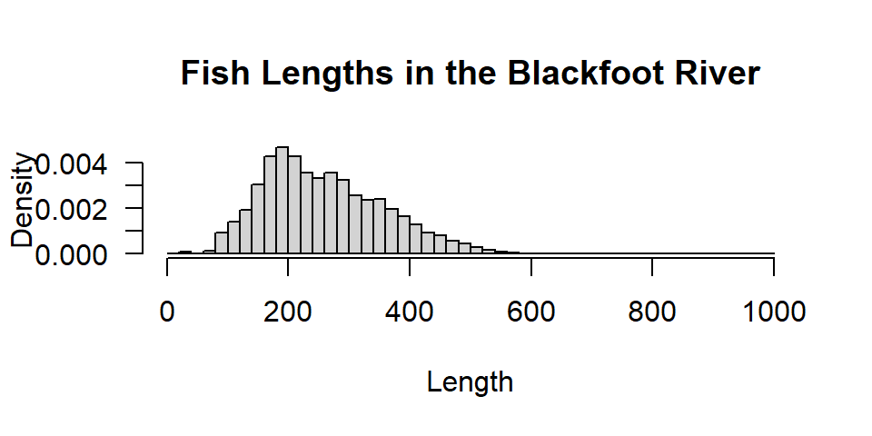

```r
hist(BlackfootFish_clean$length,
     freq = F,
     nclass = 50, ## changes the number of bins
     xlab = "Length",
     main = "Fish Lengths in the Blackfoot River",
     las = 1 ## changes orientation of axis labels
     )
```

### Side-by-Side Boxplots

The familiar boxplot is a simple display to use when the objective is to compare the distribution of a quantitative variable across different levels of a categorical variable.

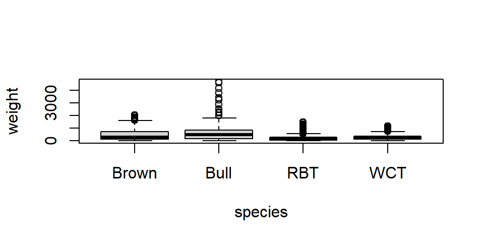

```r
## What other options are available to add to your boxplot?
boxplot(weight ~ species,
        data = BlackfootFish_clean)
```

### Bar Charts

Bar charts are an effective way to compare the frequencies of levels of a categorical variable.

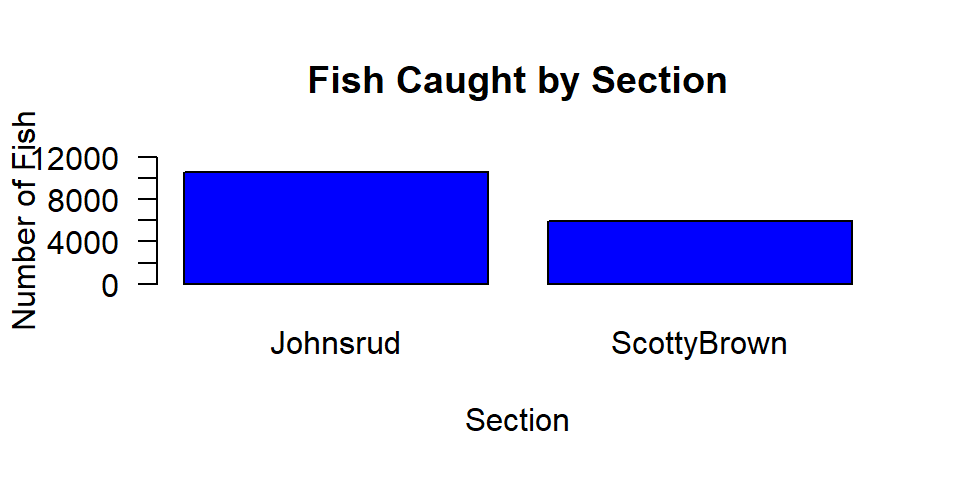

```r
section <- table(BlackfootFish_clean$section)
## tables the number of fish that were caught in each section

barplot(section,
        xlab = "Section", ## adds axis labels to plot
        ylab = "Number of Fish",
        main = "Fish Caught by Section", ## adds title to plot
        las = 1, ## changes orientation of axis labels
        col = "blue", ## specifies what color the bars should be
        ylim = c(0, 12000) ## specifies what range of y-values to plot
        )
```

### Practice: Graphing

#### Exercise 11:

```r
yearF_counts <- table(BlackfootFish_clean$yearF)
yearF_counts
```

[output not shown]

```
## < table of extent 0 >
```

```r
barplot(yearF_counts,
        xlab = "Year Caught",
        ylab = "Number of Fish",
        main = "Fish Caught by Year",
        las = 1,
        col = "blue",
        ylim = c(0,2200),
        )
```

[output not shown]

#### Exercise 12:

Make a boxplot of the fish weights over the different years in the dataset.

```r
boxplot(weight ~ yearF, data = BlackfootFish_clean)
```

[output not shown]

## Knitting/compiling

Hopefully at this point you have fixed all the code errors in the file we initially provided as you learned about the `R` code and functions. A final (and sometimes intermediate step) is to compile your Rmarkdown file into an HTML, Word, or PDF document. The compiling process will verify that the code you wrote works in the order that it is present in the document and is your reproducible result to share with colleagues and collaborators. The .Rmd is your archive of the code used to produce those results from the data.

The HTML format is the least nice for printing but also has the fewest dependencies on other software to compile. Compiling to Word requires a word processing software like Microsoft Word. Compiling to PDF either requires the `tinytex` package in `R` or a separate installation of `miktex`, so often requires additional steps beyond what we want to discuss today.

To attempt to knit to one of these formats, go to “`Knit`” and click on the triangle to select the “`Knit to ...`” version. The entire suite of code will be re-run from beginning to end and, if it works, compiled into the document type you specified.

## Exiting RStudio

Finally, when you are done with your work and attempt to exit out of RStudio, it will ask you to save your workspace. **DO NOT DO THIS!** It will just create a cluttered workspace and could even cause you to get incorrect results. In fact, you should go into the Tools -> Global Options and then make sure that “Save workspace to .RData on exit” option on the first screen you will see is set to Never. If you save your `R` code either as a .R or (better) an R Markdown (.Rmd) file, you can re-create any results by simply re-running that code or re-knitting the file. If you find that you have lots of “stuff” in your workspace because you accidentally saved your workspace, just run `rm(list = ls())`. It will delete all the data sets from your workspace.

## Additional Data Wrangling Material

### Clean Code

Yes, writing code may be completely new to you, but there is a difference between code that looks nice and code that does not. Generally, object names should be nouns and function names should be verbs. It is also important that your code looks presentable, so that a friend/college/professor can read it and understand what you are doing. For these reasons, there are style guides for writing code in `R`. The two main style guides are Google’s https://google.github.io/styleguide/Rguide.xml and the slightly more comprehensive Tidyverse style guide https://style.tidyverse.org/. Installing the `styler` package will allow you to highlight code and format it in a more legible way. Visit the tidyverse page https://style.tidyverse.org/ for more information.

### Using `lubridate` for Dates

Date-time data can be frustrating to work with in `R`, since `R` commands for date-times are generally un-intuitive and change depending on the type of date-time object being used. Moreover, the methods we use with date-times must be robust to time zones, leap days, daylight savings times, and other time related quirks, and `R` lacks these capabilities in some situations. The `lubridate` package makes it easier to do the things `R` does with date-times and possible to do things that base `R` does not.

`Lubridate` has functions that handle easy parsing of times, such as:

- `ymd()`
- `dmy()`
- `mdy()`

```r
library(lubridate)
today() # Today's date
```

```
## [1] "2026-08-12"
```

```r
now() # Today's date, with time and timezone!
```

```
## [1] "2026-08-12 09:20:02 MDT"
```

```r
surveys <- read_csv("data/surveys2.csv")
surveys_w_days <- surveys |>
  mutate(date = ymd(paste(year,
                          month,
                          day,
                          sep = "-")
                    ),
         day_of_week = wday(date, label = TRUE)
         ## Creating a day of the week variable
         ## label = TRUE prints the name, not the level!
         )
surveys_w_days |>
  head()
```

```
## # A tibble: 6 × 15
##   record_id month   day  year plot_id species_id sex   hindfoot_length weight
##       <dbl> <dbl> <dbl> <dbl>   <dbl> <chr>      <chr>           <dbl>  <dbl>
## 1     23215     1    27  1996      21 PF         F                  16      7
## 2     23216     1    27  1996       1 DM         M                  36     27
## 3     23217     1    27  1996      17 DM         M                  36     25
## 4     23218     1    27  1996      17 DM         M                  37     25
## 5     23220     1    27  1996       2 DM         F                  36     47
## 6     23221     1    27  1996      18 PF         F                  16      9
## # ℹ 6 more variables: date <date>, day_of_week <ord>, plot_type <chr>,
## #   genus <chr>, species <chr>, taxa <chr>
```

```r
surveys_w_days |>
  select(day_of_week) |>
  summary()
```

```
##   day_of_week
##  Sun    :4212
##  Sat    :4202
##  Wed    : 924
##  Mon    : 572
##  Thu    : 525
##  (Other): 772
##  NAs    : 125
```

```r
surveys_w_days |>
  filter(is.na(date) == TRUE) |>
  select(month, day) |>
  table()
```

```
##      day
## month 31
##     4 70
##     9 55
```

#### Challenge 15

> - What dates were unable to be converted?
> - Explore the results and objects in the previous sandbox to figure out why that happened.

We can pull off components of dates using a large array of `lubridate` functions, such as:

- `year()`
- `month()`
- `mday()`
- `hour()`
- `minute()`
- `second()`

For additional information about `lubridate` visit [the `lubridate` reference website](https://lubridate.tidyverse.org/) or look over the [`lubridate` cheatsheet](https://raw.githubusercontent.com/rstudio/cheatsheets/main/lubridate.pdf).

### Character Wrangling

If we inspect the day of week variable we created in the last code chunk, we’ll see that it is an ordered (<ord>) factor.

#### Challenge 16

> What are the names of the days of the week taken from the dates?

#### The `case_when()` Function

We notice that the labels for the days of the week are not necessarily what we would like to have for a graphical display of our data. To reword the names of the days of the week, we can use the `case_when()` function from `dplyr`.

The `case_when()` function can be thought of as a “generalized form for multiple `if_else()` statements.” We talked about `ifelse()` statements in the *Intermediate R* workshop, but let’s break them down here to review.

For `case_when()` the inputs are sequences of two-sided formulas. The left hand side finds the values that match the case and the right hand side says what should be done with these matches.

Let’s look at this in action!

```r
surveys_days_full <- surveys_w_days |>
  mutate(day_of_week = case_when(day_of_week == "Mon" ~ "Monday",
                             day_of_week == "Tue" ~ "Tuesday",
                             day_of_week == "Wed" ~ "Wednesday",
                             day_of_week == "Thu" ~ "Thursday",
                             day_of_week == "Fri" ~ "Friday",
                             day_of_week == "Sat" ~ "Saturday",
                             day_of_week == "Sun" ~ "Sunday")
         )
glimpse(surveys_days_full$day_of_week)
```

```
##  chr [1:11332] "Saturday" "Saturday" "Saturday" "Saturday" "Saturday" ...
```

> NOTE:

> If you only want to recode a couple levels of a variable, you can still use `case_when()` without specifying the behavior for **ALL** levels. See the example below:

```r
# Create a variable weekday that takes on a value of 0 for Saturday/Sunday
# and 1 otherwise and recodes Friday to missing
surveys_weekday <- surveys_w_days |>
  mutate(weekday = case_when(day_of_week == "Sat" ~ 0,
                             day_of_week == "Sun" ~ 0,
                             day_of_week == "Fri" ~ as.numeric(NA),
                             TRUE ~ 1))

surveys_weekday |>
  count(weekday)
```

```
## # A tibble: 3 × 2
##   weekday     n
##     <dbl> <int>
## 1       0  8414
## 2       1  2589
## 3      NA   329
```

But, perhaps these days are not in the order that we want them to be in.

##### Challenge 17

> What order did `R` put the days of the week in? What data type is `day_of_week` now?

There are small differences between character data types and factor data types. Typically, `R` uses factors to handle categorical variables, variables that have a fixed and known set of possible values. Factors are also helpful for reordering character vectors to improve display. However, factors are often difficult to work with. Enter the `forcats` package, whose goal is to provide a suite of tools that solve common problems with factors, including changing the order of levels or the values.

The order of the levels `R` chose may not be what we wanted, but we can reorder them using the `fct_relevel()` function from the `forcats` package (the [`forcats` cheatsheet link](https://raw.githubusercontent.com/rstudio/cheatsheets/main/factors.pdf). The function takes three arguments:

1. the data
2. the factor to be reordered
3. the order of the new levels separated by commas

This process looks like this:

```r
surveys_edited <- surveys_days_full |>
  mutate(day_of_week = fct_relevel(day_of_week,
                                   "Monday",
                                   "Tuesday",
                                   "Wednesday",
                                   "Thursday",
                                   "Friday",
                                   "Saturday",
                                   "Sunday")
  )
glimpse(surveys_edited$day_of_week)
```

```
##  Factor w/ 7 levels "Monday","Tuesday",..: 6 6 6 6 6 6 6 6 6 6 ...
```

##### Challenge 18

> Verify that `R` put the days in the order that you specified!

### Relational Data with `dplyr`

It is rare that data analyses, especially with longitudinal measurements, involve only a single table of data. More typically, you have multiple tables of data, describing different aspects of your study. When you embark on analyzing your data, these different data tables need to be combined. Collectively, multiple tables of data are called *relational data*, as the data tables are not independent, rather they relate to each other.

Relations are defined between a pair of data tables. There are three families of joining operations: mutating joins, filtering joins, and set operations. Today we will focus on mutating joins.

The `survey` data have two other data tables they are related to: `plots` and `species`. Load in these data and inspect them to get an idea of how they relate to the `survey` data we’ve been working with.

```r
plots <- read_csv("data/plots.csv")
head(plots)
```

```
## # A tibble: 6 × 2
##   plot_id plot_type
##     <dbl> <chr>
## 1       1 Spectab exclosure
## 2       2 Control
## 3       3 Long-term Krat Exclosure
## 4       4 Control
## 5       5 Rodent Exclosure
## 6       6 Short-term Krat Exclosure
```

Columns in the `plots.csv` file:

| Column | Description |
| --- | --- |
| plot_id | ID of a particular plot |
| plot_type | type of plot |

```r
species <- read_csv("data/species.csv")
head(species)
```

```
## # A tibble: 6 × 4
##   species_id genus            species         taxa
##   <chr>      <chr>            <chr>           <chr>
## 1 AB         Amphispiza       bilineata       Bird
## 2 AH         Ammospermophilus harrisi         Rodent
## 3 AS         Ammodramus       savannarum      Bird
## 4 BA         Baiomys          taylori         Rodent
## 5 CB         Campylorhynchus  brunneicapillus Bird
## 6 CM         Calamospiza      melanocorys     Bird
```

Columns in the `species.csv` file:

| Column | Description |
| --- | --- |
| species_id | 2-letter code |
| genus | genus of animal |
| species | species of animal |
| taxon | e.g. Rodent, Reptile, Bird, Rabbit |

The variables used to connect a pair of tables are called *keys*. A key is a variable that uniquely identifies an observation in that table. What are the keys for each of the three data tables? (hint: What combination of variables uniquely identifies a row in that data frame?)

#### Quiz:

1. What is the key for the plots data table?
   1. plot_id
   2. plot_type
2. What is the key for the species data table?
   1. species
   2. species_id
   3. genus
   4. taxa
3. What is the key for the surveys data table?
   1. species_id
   2. plot_id
   3. record_id
   4. month
   5. day
   6. year
   7. sex
   8. hindfoot_length
   9. weight

There are two types of keys:

- A *primary key* uniquely identifies an observation in its own table.
- A *foreign key* uniquely identifies an observation in another table.

A primary key and the corresponding foreign key form a *relation* between the two data tables. These relations are typically many-to-one, though they can be 1-to-1. For example, there are many rodents captured that are of one species_id, hence a many-to-one relationship.

For me, the easiest way to think about the relationships between the different data tables is to draw a picture:

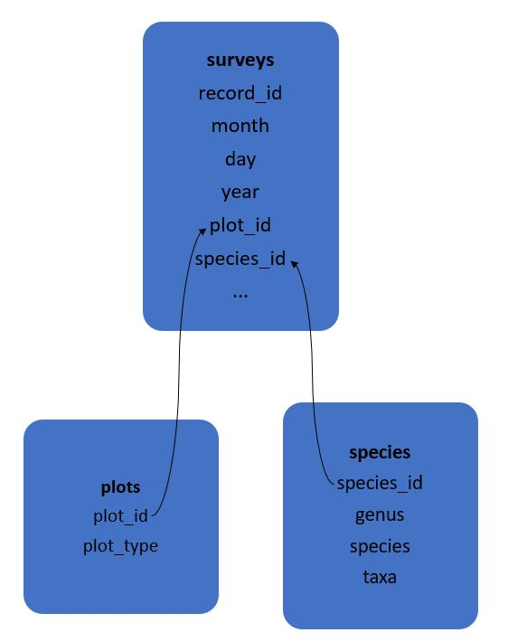

Wickham, H. and Grolemund, G. (2017) *R for Data Science*. Sebastopol, California: O’Reilly.

#### Joining Relational Data

The tool that we will be using is called a *mutating join*. A mutating join is how we can combine variables from two tables. The join matches observations by their keys, and then copies variables from one table to the other. Similar to `mutate()` these join functions add variables to the right of the existing data frame, hence their name. There are two types of mutating joins, the inner join and the outer join.

#### Inner Join

The simplest join is an *inner join*, which creates a pair of observations whenever their keys are equal. This join will output a new data frame that contains the key, the values of `x`, and the values of `y`. Importantly, this join deletes observations that do not have a match.

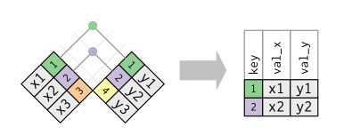

Wickham, H. and Grolemund, G. (2017) *R for Data Science*. Sebastopol, California: O’Reilly.

#### Outer Join

While an inner join only keeps observations with keys that appear in both tables, an *outer join* keeps observations that appear in *at least one* of the data tables. When joining `x` with `y`, there are three types of outer join:

- A *left join* keeps all of the observations in `x`.
- A *right join* keeps all of the observations in `y`.
- A *full join* keeps all of the observations in both `x` and `y`.

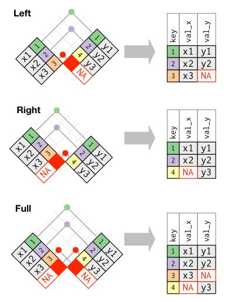

Wickham, H. and Grolemund, G. (2017) *R for Data Science*. Sebastopol, California: O’Reilly.

The left join is the most common, as you typically have a data frame (`x`) that you wish to add additional information to (the contents of `y`). This join will preserve the contents of `x`, even if there is not a match for them in `y`.

#### Joining `surveys_edited` Data

```r
combined <- surveys_edited |>
              left_join(plots, by = "plot_id") |>  # adding the type of plot
              left_join(species, by = "species_id") # adding the genus, species, and taxa
glimpse(combined)
```

```
## Rows: 11,332
## Columns: 19
## $ record_id       <dbl> 23215, 23216, 23217, 23218, 23220, 23221, 23222, 23223…
## $ month           <dbl> 1, 1, 1, 1, 1, 1, 1, 1, 1, 1, 1, 1, 1, 1, 1, 1, 1, 1, …
## $ day             <dbl> 27, 27, 27, 27, 27, 27, 27, 27, 27, 27, 27, 27, 27, 27…
## $ year            <dbl> 1996, 1996, 1996, 1996, 1996, 1996, 1996, 1996, 1996, …
## $ plot_id         <dbl> 21, 1, 17, 17, 2, 18, 1, 2, 17, 2, 1, 12, 21, 18, 17, …
## $ species_id      <chr> "PF", "DM", "DM", "DM", "DM", "PF", "DM", "DO", "DM", …
## $ sex             <chr> "F", "M", "M", "M", "F", "F", "M", "M", "F", "M", "F",…
## $ hindfoot_length <dbl> 16, 36, 36, 37, 36, 16, 34, 37, 39, 40, 27, 39, 21, 16…
## $ weight          <dbl> 7, 27, 25, 25, 47, 9, 27, 66, 49, 54, 38, 51, 16, 9, 5…
## $ date            <date> 1996-01-27, 1996-01-27, 1996-01-27, 1996-01-27, 1996-…
## $ day_of_week     <fct> Saturday, Saturday, Saturday, Saturday, Saturday, Satu…
## $ plot_type.x     <chr> "Long-term Krat Exclosure", "Spectab exclosure", "Cont…
## $ genus.x         <chr> "Perognathus", "Dipodomys", "Dipodomys", "Dipodomys", …
## $ species.x       <chr> "flavus", "merriami", "merriami", "merriami", "merriam…
## $ taxa.x          <chr> "Rodent", "Rodent", "Rodent", "Rodent", "Rodent", "Rod…
## $ plot_type.y     <chr> "Long-term Krat Exclosure", "Spectab exclosure", "Cont…
## $ genus.y         <chr> "Perognathus", "Dipodomys", "Dipodomys", "Dipodomys", …
## $ species.y       <chr> "flavus", "merriami", "merriami", "merriami", "merriam…
## $ taxa.y          <chr> "Rodent", "Rodent", "Rodent", "Rodent", "Rodent", "Rod…
```

If the keys being used have different names in the data tables, you can use `by=c("a" = "b")` where `a` is the key name in the `x` dataset and `b` is the name in the `y` dataset. Or you could mutate the variable names so that they do match prior to using `left_join`.

### Reshaping Data

Data Carpentry’s [spreadsheet lesson (link)](https://datacarpentry.org/spreadsheet-ecology-lesson/01-format-data/), discusses how to structure our data leading to the four rules defining a tidy dataset:

1. Each variable has its own column
2. Each observation has its own row
3. Each value must have its own cell
4. Each type of observational unit forms a table

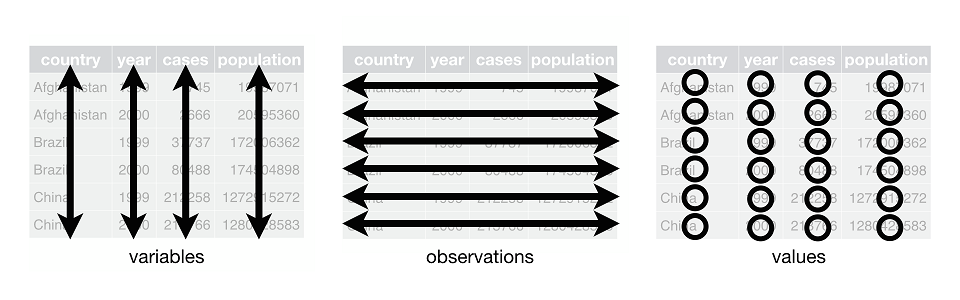

https://datacarpentry.org/spreadsheet-ecology-lesson/01-format-data/

Here we examine the fourth rule: Each type of observational unit forms a table.

In `surveys_edited` , the rows of `surveys_edited` contain the values of variables associated with each record (the unit), values such as the weight or sex of each animal associated with each record. What if instead of comparing records, we wanted to compare the different mean weights of each genus between plots? (Ignoring `plot_type` for simplicity).

We’d need to create a new table where each row (the unit) is comprised of values of variables associated with each plot. In practical terms this means the values in `genus` would become the names of column variables and the cells would contain the values of the mean weight observed on each plot.

Having created a new table, it is therefore straightforward to explore the relationship between the weight of different genera within, and between, the plots. The key point here is that we are still following a tidy data structure, but we have **reshaped** the data according to the observations of interest: average genus weight per plot instead of recordings per date.

The opposite transformation would be to transform column names into values of a variable.

We can do both these of transformations with two `tidyr` functions, `pivot_longer()` and `pivot_wider()`.

### Pivoting to a Wider Table

`pivot_wider()` takes three principal arguments:

1. the data
2. the column whose values will become new column names.
3. the column whose values will fill the new columns.

Further arguments include `fill` which, if set, fills in missing values with the value provided.

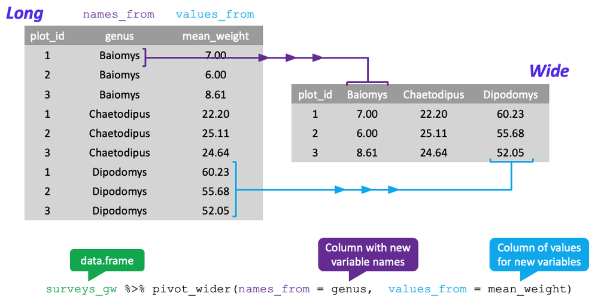

https://datacarpentry.org/spreadsheet-ecology-lesson/01-format-data/

Let’s use `pivot_wider()` to transform surveys to find the mean weight of each genus in each plot over the entire survey period. We use `filter()`, `group_by()` and `summarize()` to filter our observations and variables of interest, and create a new variable for the `mean_weight`. We use the pipe as before too.

```r
surveys_gw <- combined |>
  filter(!is.na(weight)) |>
  group_by(plot_id, genus) |>
  summarize(mean_weight = mean(weight))
```

[output not shown]

```
## Error in `group_by()`:
## ! Must group by variables found in `.data`.
## ✖ Column `genus` is not found.
```

```r
glimpse(surveys_gw)
```

[output not shown]

```r
surveys_gw |>
  head()
```

[output not shown]

```r
surveys_wide <- surveys_gw |>
  pivot_wider(names_from = genus, values_from = mean_weight)
```

[output not shown]

```
## Error:
## ! object 'surveys_gw' not found
```

```r
glimpse(surveys_wide)
```

[output not shown]

```r
surveys_wide |>
  head()
```

[output not shown]

##### Challenge 19

> Pivot the `combined` data frame to a wide format, with `year` as columns, `plot_id` as rows, and the number of genera per plot as the values. You will need to summarize before reshaping, and use the function `n_distinct()` to get the number of unique genera within a particular chunk of data. It’s a powerful function! See `?n_distinct` or go to https://dplyr.tidyverse.org/reference/n_distinct.html for more information.

> Save the wide dataset as an object, with an intuitive name! Then use `glimpse` to take a look at the structure.

```r
## Make a wide data frame by pivoting on year.
## Fill the values in these columns with the number of genera per plot.
## Make sure to save the new dataset with an intuitive name!
```

#### Pivoting to a Longer Table

The opposing situation could occur if we had been provided with data in the form of `surveys_wide`, where the genus names are column names, but we wish to treat them as values of a genus variable instead. This task is extremely common in longitudinal data where the columns are the measurement events over time on the same variable and the rows are for the locations or subjects and we want to align all the responses in one long vector for plotting (e.g., `ggplot`) or analyses.

In this situation we are gathering the column names and turning them into a pair of new variables. One variable represents the column names as values, and the other variable contains the values previously associated with the column names.

`pivot_longer()` takes four principal arguments:

1. the data
2. the columns we wish to pivot into a single column
3. the name of the new column to create to store the names of each selected column
4. the name of the new column to create to store the data filled in each cell

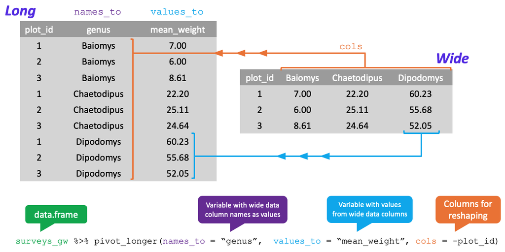

https://datacarpentry.org/spreadsheet-ecology-lesson/01-format-data/

To recreate `surveys_gw` from `surveys_wide` we would create a key called `genus` and value called `mean_weight` and use all columns except `plot_id` for the key variable. Here we drop the `plot_id` column with a minus sign.

```r
surveys_long <- surveys_wide |>
  pivot_longer(cols = -plot_id, names_to = "genus", values_to = "mean_weight")
```

[output not shown]

```
## Error:
## ! object 'surveys_wide' not found
```

```r
glimpse(surveys_long)
```

```
## Error:
## ! object 'surveys_long' not found
```

We could also have used a specification for what columns to include. This can be useful if you have a large number of identifying columns, and it’s easier to specify what to gather than what to leave alone. And if the columns are in a row, we don’t even need to list them all out - just use the `:` operator!

```r
surveys_wide |>
  pivot_longer(cols = Chaetodipus:Sigmodon, names_to = "genus",
               values_to = "mean_weight") |>
  head()
```

[output not shown]

```
## Error:
## ! object 'surveys_wide' not found
```

##### Challenge 20

> Take the `surveys_wide_genera` dataset and use `pivot_longer()` to pivot it to the long format it was in before, so that each row is a unique `plot_id` by `year` combination.

> **HINT**: The year column names look like numbers so you need to use back ticks (“`”) to indicate they are variables instead of numbers.

```r
## Now take the surveys_wide_genera dataset, and make it long again, by
## (re)pivoting on the year columns.

names(surveys_wide_genera)
```

```
## Error:
## ! object 'surveys_wide_genera' not found
```

##### Challenge 21 Part 1

> The `combined` dataset has two measurement columns: `hindfoot_length` and `weight`. This makes it difficult to do things like look at the relationship between mean values of each measurement per year in different plot types.

> Let’s walk through a common solution for this type of problem.

> First, use `pivot_longer()` to create a dataset called `combined_longer` where we have a names column called `measurement` and a values column that takes on the value of either `hindfoot_length` or `weight`.

> **HINT**: You’ll need to specify which columns to pivot into longer format!

```r
## Use pivot_long() to create an even longer dataset.
## Create a column called measurement, containing the hindfoot and weight columns
## And a value column that takes on the value of either of these measurements
## Hint: You'll need to specify which columns are being used to pivot!
```

##### Challenge 21 Part 2

> With this new dataset, `combined_longer`, calculate the average of each `measurement` in each `year` for each different `plot_type`.

> Then pivot these summaries into a dataset with a column for `hindfoot_length` and `weight`.

> **HINT**: This sounds like you want to pivot the data to be a wider format!

```r
## With this new very long dataset, calculate the average of each
## measurement in each year for each different plot_type.



## Now pivot these summaries into a wide dataset.
## With a columns for hindfoot_length and weight.
## Filled with the summary values you calculated.
```